# Modeling land-use change in Loudoun County using logistic regression

2024-07-13

## Introduction

Many cities/counties in the United States have been experiencing accelerated urban growth. Loudoun county has been one of the fastest growing areas in the U.S for the last two decades. Low-density residential and commercial settlements have spilled well beyond recognized urban boundaries. The urban expansion not only consumes forest and agricultural lands, but also breaks the natural landscape into fragments. Such development may cause many negative environmental impacts with respect to water quality, soil erosion, air pollution, local climate, and biodiversity. For this lab, we’ll predict future land-cover change locations by combining spatial statistical models with spatially explicit data in the R programming environment. We will prepare GIS datasets to build a logistic regression model and then use the logistic model to estimate the probability of land change for each 30m resolution pixel.

## Logistic regression

For our logistic regression model, each “observation” is a grid cell (30m pixel). The dependent variable is a binary presence or absence event, where 1=forest-to-urban change and 0=stable forest (forest-to-forest), for the period 1992–2001. The following logistic function gives the probability of forest loss as a function of the predictors: p̂ = exp(b0 + b1x1 + b2x2 + … bnxn)/(1 + exp(b0 + b1x1 + b2x2 + … bnxn)) Model predictors (xi) can be user selected biophysical (e.g., elevation, slope, distance to roads) and socio-economic (e.g., population, income) variables.

## The dependent variable layer

Please use the land cover maps (loudoun1992.tif and loudoun2001.tif) to identify forest-to-urban change and stable forest pixels. For this dependent variable raster layer, code all forest-to-urban change locations as 1 and stable forest locations as 0. All other locations should be coded as NoData.

For both loudoun1992.tif and loudoun2001.tif files, the land cover classes are coded as follows: 1: Forest 2: Urban 3: Water 4: Agricultural land 5: Barren land 6: Wetland

```r
library(terra)
```

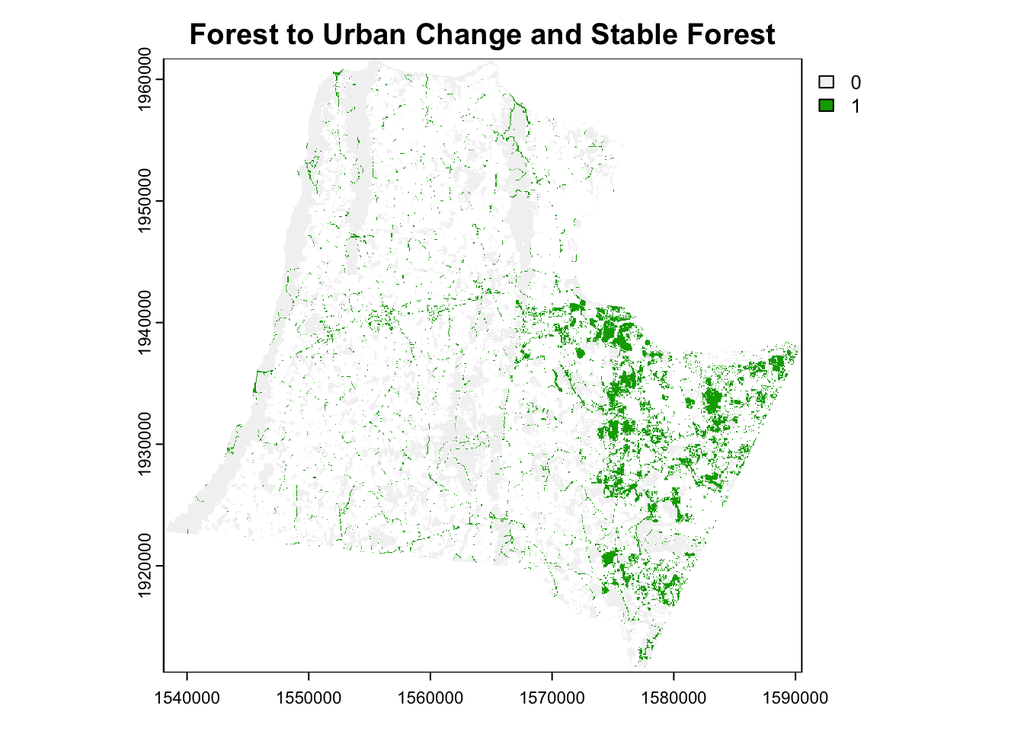

```r
# Load the land cover maps
lc1992 <- rast('loudoun1992.tif')
lc2001 <- rast('loudoun2001.tif')

# Define the codes for forest and urban in your land cover maps
forest_code <- 1  # Code for forest
urban_code <- 2   # Code for urban

# Identify forest-to-urban change (1) and stable forest (0)
# Create an empty raster with the same dimensions as the input rasters
change_layer <- rast(lc1992)
values(change_layer) <- NA

# Code forest-to-urban change locations as 1
forest_to_urban <- (lc1992 == forest_code) & (lc2001 == urban_code)
values(change_layer)[which(values(forest_to_urban))] <- 1

# Code stable forest locations as 0
stable_forest <- (lc1992 == forest_code) & (lc2001 == forest_code)
values(change_layer)[which(values(stable_forest))] <- 0

# Plot the result
plot(change_layer, main = "Forest to Urban Change and Stable Forest")
```

## Predictors: Elevation, Slope, Distance-to-road The DEM (30m resolution) can be downloaded through library ‘FedData’. Please install this library.

The Road layer is available in the lab folder [Roads.shp].

You’ll generate three raster layers (elevation, slope, distance-to-road) in the R environment. These raster layers should have the same spatial extent (col, row number) as those of land cover maps. R terra library is very useful for this lab.

## Select a subset of total pixels for logistic model development

Within the forest-to-urban change and stable forest area mask, identify about 5% of total pixels for logistic model development. You may generate Random Points to support this task. About 5% of pixels can be randomly chosen to support your model development.

## Develop the training data set for urban growth simulation

For the randomly selected locations or points, please extract pixel values from the dependent variable raster layer (y), elevation layer (x1), slope layer(x2), and distance-to-road raster layer (x3). Combine the extracted pixel values and generate a dataframe (i.e., train_data) with four data columns (y, elev, slope, distr).

## Using glm() to build the logistic regression model

Makes it very easy to fit a logistic regression model. The function to be called is glm(). Use the following command line to build the logistic regression model:

glm<-glm(formula = y ~ elev + slope + distr, family = “binomial”, data = train_data)

## Use summary command to see the results from the logistic regression model:

summary(glm)

## Generate the final probability/suitability map

Please search online resource on how we generate predictions for all observations, given that glm model is ready.

## Deliverables

1. Upload your lab report (Markdown-derived HTML) to Canvas.
2. Include the final probability map.